# 2023 Arizona Profile

Return to the main page

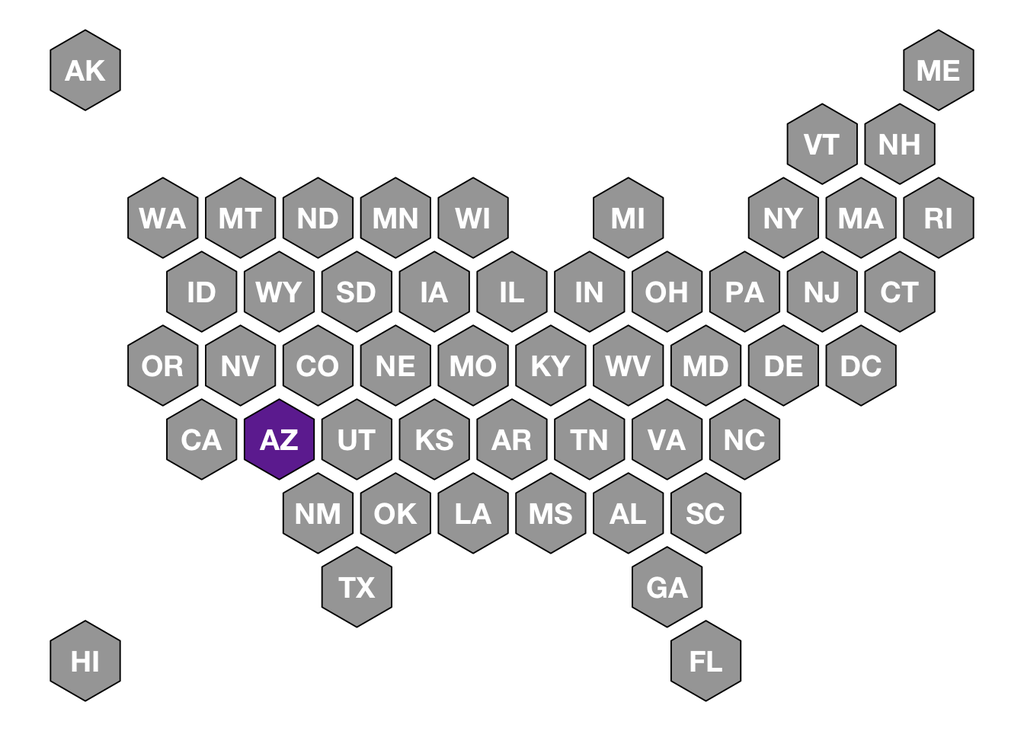

2023 State Profile - Arizona

### Child Maltreatment Victims

### About this Report

This report provides data from 2023 on child maltreatment victims in Arizona. Child abuse and neglect, also referred to as child maltreatment, encompasses any recent action or failure to act by a parent or caregiver that results in significant physical or emotional harm, sexual abuse, exploitation, or death. It also includes any behavior (or lack of action) that poses an immediate risk of serious harm to a child. For more information on child maltreatment, visit the [Children’s Bureau’s Child Maltreatment page](https://www.acf.hhs.gov/cb/data-research/child-maltreatment) from the Office of the Administration for Children and Families. The data for this report was sourced from the [Kids Count Data Center](https://datacenter.kidscount.org/data).

### Victims of child maltreatment

In 2023, there were 1,615,120 children in Arizona. During that same year, state officials reported that 11,577 children were victims of maltreatment, representing a rate of 7 per 1,000 children in the population. This report highlights the percentage of child maltreatment victims in Arizona, broken down by the following categories:

- Gender
- Race and Ethnicity
- Age
- Maltreatment Type

### Gender

Below is a table that displays the percentage of child maltreatment victims in Arizona broken down by gender.  
*Note: N.R. means no data reported or less than <.5% reported.

|  | Maltreatment Victims | Maltreatment Victims |  | State Child population | State Child population |  |  |
| --- | --- | --- | --- | --- | --- | --- | --- |
| Male | 49.0% |  |  | 51.0% |  |  |  |
| Female | 51.0% |  |  | 49.0% |  |  |  |

### Race and Ethnicity

Below is a table that displays the percentage of child maltreatment victims in Arizona broken down by race and ethnicity.  
*Note: N.R. means no data reported or less than <.5% reported.

|  | Maltreatment Victims | Maltreatment Victims |  | State Child population | State Child population |  |  |
| --- | --- | --- | --- | --- | --- | --- | --- |
| Black / African American | 8.0% |  |  | 6.0% |  |  |  |
| Asian / Pacific Islander | N.R. |  |  | 3.0% |  |  |  |
| American Indian / Alaska Native | 3.0% |  |  | 4.0% |  |  |  |
| Hispanic / Latino | 35.0% |  |  | 44.0% |  |  |  |
| Multiracial | 3.0% |  |  | 5.0% |  |  |  |
| White | 23.0% |  |  | 37.0% |  |  |  |
| Unknown | 28.0% |  |  | N.R. |  |  |  |

### Age

Below is a table that displays the percentage of child maltreatment victims in Arizona broken down by age.  
*Note: N.R. means no data reported or less than <.5% reported.

|  | Maltreatment Victims | Maltreatment Victims |  | State Child population | State Child population |  |  |
| --- | --- | --- | --- | --- | --- | --- | --- |
| 0 to 4 | 45.0% |  |  | 24.8% |  |  |  |
| 5 to 10 | 27.0% |  |  | 33.4% |  |  |  |
| 11 to 13 | 12.0% |  |  | 17.2% |  |  |  |
| 14 to 17 | 15.0% |  |  | 24.6% |  |  |  |

### Type of Maltreatment

Below is a table that displays the percentage of child maltreatment victims in Arizona broken down by type of maltreatment.  
*Note: N.R. means no data reported or less than <.5% reported.

|  | Maltreatment Victims | Maltreatment Victims |  | USA Child Population | USA Child Population |  |  |
| --- | --- | --- | --- | --- | --- | --- | --- |
| Emotional Abuse | N.R. |  |  | 7.0% |  |  |  |
| Medical Neglect | N.R. |  |  | 2.0% |  |  |  |
| Neglect | 88.0% |  |  | 74.0% |  |  |  |
| Physical Abuse | 15.0% |  |  | 17.0% |  |  |  |
| Sexual Abuse | 6.0% |  |  | 10.0% |  |  |  |
| Other Maltreatment | N.R. |  |  | 3.0% |  |  |  |

This report was designed by [Analytics Made Accessible LLC](https://www.anyamemensah.com/about).

[figure not shown]